# Univariate QTL Mapping with wgAim

Author

Julian Taylor & Ari Verbyla

Published

May 28, 2026

## 1 Overview

This vignette demonstrates the complete univariate **wgAim** QTL mapping pipeline for a biparental mapping population. The pipeline has three stages:

1. **Pre-analysis** — convert a raw `cross` object into the analysis-ready `wgCross` format using `primeCross()`.
2. **Analysis** — fit a whole-genome composite model and iteratively select QTL using `qtlAim()`.
3. **Post-analysis** — interrogate, summarise, and visualise the detected QTL using the `print`, `summary`, and `plot` methods, and refine QTL positions with `fineMap()`.

**Requires:** ASReml-R V4. The vignette is pre-rendered so no licence is needed to read it. Run the code chunks only if you have ASReml-R installed.

## 2 Mathematical Framework

### 2.1 The base linear mixed model

Let $\boldsymbol{y}$ be the $n \times 1$ vector of phenotypic observations for a single trait measured on $n$ lines in a field trial. The starting point for any `qtlAim()` analysis is a converged **base linear mixed model** (LMM) of the form

$$\boldsymbol{y} = \boldsymbol{X}\boldsymbol{\tau}
+ \boldsymbol{Z}_u\boldsymbol{u}
+ \boldsymbol{Z}_g\boldsymbol{g}
+ \boldsymbol{e},$$

where:

- $\boldsymbol{X}$ is the $n \times p$ design matrix for the **fixed effects** $\boldsymbol{\tau}$, which capture known, systematic sources of variation such as replicate, range or row trend effects.
- $\boldsymbol{Z}_u$ is the design matrix for **peripheral random effects** $\boldsymbol{u}$, representing nuisance sources of variation in the experimental layout — for example, incomplete blocks, rows, ranges, or other spatial or management groupings. Specifically, $\boldsymbol{u} \sim \mathcal{N}(\boldsymbol{0},\, \sigma^2_u\,\boldsymbol{I})$.
- $\boldsymbol{Z}_g$ is the design matrix linking observations to **genetic line effects** $\boldsymbol{g}$, with $\boldsymbol{g} \sim \mathcal{N}(\boldsymbol{0},\, \sigma^2_g\,\boldsymbol{I})$. This term accounts for line-to-line genetic variation prior to any QTL modelling.
- $\boldsymbol{e} \sim \mathcal{N}(\boldsymbol{0},\, \sigma^2\,\boldsymbol{R})$ is the vector of residual errors, where $\boldsymbol{R}$ is a structured correlation matrix that captures any remaining spatial or within-trial correlation among observations (for example, an AR1$\times$AR1 surface over rows and columns).

The base model is fitted and checked for convergence before being passed to `qtlAim()`. It defines the environmental and design structure that must be accounted for before the genetic signal can be reliably extracted.

### 2.2 Introducing additive genetic effects

When QTL mapping is the objective, the genetic term $\boldsymbol{g}$ is decomposed into two components: an **additive genetic effect** $\boldsymbol{a}$ that captures the cumulative contribution of loci spread across the genome, and a **residual genetic effect** $\boldsymbol{p}$ that absorbs any remaining line-level genetic signal not accounted for by the marker/interval data. The augmented model becomes

$$\boldsymbol{y} = \boldsymbol{X}\boldsymbol{\tau}
+ \boldsymbol{Z}_u\boldsymbol{u}
+ \boldsymbol{Z}_g\boldsymbol{a}
+ \boldsymbol{Z}_g\boldsymbol{p}
+ \boldsymbol{e},$$

where $\boldsymbol{a}$ is modelled via the **whole-genome composite term** described below, and $\boldsymbol{p} \sim \mathcal{N}(\boldsymbol{0},\, \sigma^2_p\,\boldsymbol{I})$ is the residual polygenic background that ensures the genetic effects not captured by detected QTL are not forced into the residual. Retaining $\boldsymbol{p}$ is important: it prevents inflation of the QTL effects and provides a more honest partition of genetic variance.

### 2.3 The whole-genome composite model

`qtlAim()` represents the additive genetic term $\boldsymbol{a}$ as a **composite genome-wide random effect** that simultaneously models the contribution of all $p$ marker intervals. Let $\boldsymbol{M}$ be the $n \times p$ matrix of scaled marker or interval genotype scores (coded $-1$ / $+1$ for the two parental alleles). The two equivalent computational paths used are:

- **vm path** ($p > n$): The aggregate marker signal is absorbed into a genomic relationship matrix $\boldsymbol{K} = \tfrac{1}{p}\boldsymbol{M}\boldsymbol{M}^{\top}$, and $\boldsymbol{a} \sim \mathcal{N}(\boldsymbol{0},\, \sigma^2_a\,\boldsymbol{K})$. This is the standard Gaussian process / GBLUP formulation, efficient when there are more markers than lines.
- **mbf path** ($n \geq p$): Each marker effect is treated as an independent random regression coefficient, $\boldsymbol{a} = \boldsymbol{M}\boldsymbol{q}$ with $\boldsymbol{q} \sim \mathcal{N}(\boldsymbol{0},\, \sigma^2_q\,\boldsymbol{I}_p)$, equivalent to ridge regression on the marker scores. This path is preferred when lines outnumber markers.

Both paths yield identical QTL selection results; the engine selects the appropriate path automatically based on the dimensions of $\boldsymbol{M}$, or the user can force the mbf path via `force = TRUE`.

### 2.4 The likelihood ratio test and forward selection

Putative QTL are detected by **forward selection**. To confirm the significance of a putative QTL somewhere on the genome, a **likelihood ratio test** (LRT) is used to compare the additive LMM against the baseline LMM with both models potetially containing selected QTL from earlier iterations.

$$\Lambda = -2\!\left(\ell_{\text{base}} - \ell_{\text{full}}\right)
\;\stackrel{\text{approx.}}{\sim}\;
\chi^2_{1},$$

where $\ell$ denotes the residual log-likelihood. If $\Lambda$ exceeds the $\chi^2_1$ threshold at the family-wise significance level `TypeI` (default 0.05) a search putative QTL is underatken. No Bonferroni or any other multiple comparison correction is needed for this test as the `TypeI` value acts like a family-wise error rate (see Verbyla et al. 2007 for more details.)

Once the null hypothesis of no QTL is rejected genome-wide **outlier statistics** are calculated for every interval where, for interval $k$, is

$$o_k = \frac{\tilde{q}_k^2}{\tilde{v}_k},$$

where $\tilde{q}_k$ is the posterior mean (BLUP) of the interval effect from the composite random term and $\tilde{v}_k$ is its posterior variance. The interval with the largest $o_k$ is the candidate for promotion to a fixed or random QTL.

The confirmed QTL is retained as a fixed or random effect and the composite random term is rebuilt on the remaining intervals, ensuring subsequent iterations condition on all previously detected effects. This continues until the null hypothesis is retained using the LRT threshold, yielding a final model with $s$ fixed or random QTL effects alongside the remaining additive effects and residual genetic effects. The final model becomes

$$\boldsymbol{y} = \boldsymbol{X}\boldsymbol{\tau}
+ \sum_{k=1}^{s} \hat{\beta}_k\,\boldsymbol{x}_k
+ \boldsymbol{Z}_u\boldsymbol{u}
+ \boldsymbol{Z}_g\boldsymbol{a}_{-s}
+ \boldsymbol{Z}_g\boldsymbol{p}
+ \boldsymbol{e},$$

where $\hat{\beta}_k$ is the estimated allele substitution effect for the $k$-th QTL and $\boldsymbol{x}_k$ is the corresponding column of interval genotype scores and $\boldsymbol{a}_{-s} = \boldsymbol{M}_{-s}\boldsymbol{q}_{-s}$ where the $\boldsymbol{M}_{-s}$ denotes $\boldsymbol{M}$ with an omission of markers/intervals in the windows of the QTL selected.

## 3 Data Preparation — `primeCross()`

`primeCross()` converts a `cross` object from the **qtl** package into a `wgCross` object ready for `qtlAim()`. Its key task is to construct the **interval genotype scores** used in interval mapping — Haldane-weighted midpoint summaries of the flanking marker genotypes that place a virtual observation at the centre of each inter-marker interval.

```r
data(genoRxK,  package = "wgAim")
data(phenoRxK, package = "wgAim")
```

```r
rxk <- primeCross(genoRxK, type = "interval", id = "Genotype")
```

The resulting `wgCross` object stores one list element per chromosome. Each element contains `$map` (cM positions), `$data` (original marker genotypes), and `$interval.data` (the derived interval scores). A brief summary of the map:

```r
n_chr <- length(rxk$geno)
n_int <- sum(sapply(rxk$geno, function(ch) ncol(ch$interval.data)))
n_mk  <- sum(sapply(rxk$geno, function(ch) ncol(ch$data)))
cat(sprintf("Chromosomes : %d\n", n_chr))
```

```
Chromosomes : 27
```

```r
cat(sprintf("Markers     : %d\n", n_mk))
```

```
Markers     : 441
```

```r
cat(sprintf("Intervals   : %d\n", n_int))
```

```
Intervals   : 414
```

The full linkage map can be visualised with `linkMap()`:

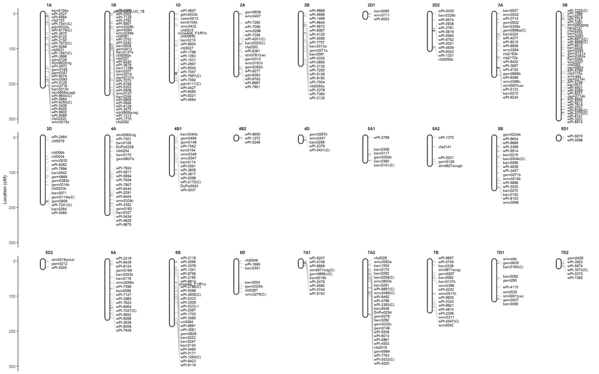

RAC875 × Kukri linkage map displayed in three rows. Marker names are shown on each chromosome; tick marks indicate marker positions.

```r
linkMap(rxk, nrow = 3, marker.names = "all") +
  theme(plot.title = element_blank())
```

## 4 QTL Mapping — `qtlAim()`

### 4.1 Base model

The starting point is a converged ASReml-R model that captures the experimental design without any genomic term. For this trial — a randomised complete block design with spatial trend — we include a fixed range effect and random row and genotype terms:

```r
pheno <- phenoRxK
pheno$Genotype <- factor(pheno$Genotype)
pheno$Row      <- factor(pheno$Row)
pheno$Range    <- factor(pheno$Range)

base_yld <- asreml(
  fixed     = yld ~ Range,
  random    = ~ Genotype + Row,
  data      = pheno,
  na.action = na.method(x = "include")
)
base_yld <- update(base_yld)
```

### 4.2 Running `qtlAim()`

`qtlAim()` takes the fitted base model and the `wgCross` object. The `merge.by` argument names the column shared between the phenotypic data and `rxk$pheno` that identifies lines. An exclusion window of 50 cM prevents closely linked false positives from being selected in consecutive iterations:

```r
qtl_yld <- qtlAim(
  baseModel        = base_yld,
  genObj           = rxk,
  merge.by         = "Genotype",
  exclusion.window = 50,
  TypeI            = 0.05,
  trace            = FALSE
)
```

On completion `qtlAim()` returns an object of class `"qtlAim"` and prints a brief summary to the console. The engine path (vm or mbf) is chosen automatically based on the ratio of markers to lines, and the number of detected QTL reflects how many intervals cleared the LRT threshold:

```r
cat("Class  :", paste(class(qtl_yld), collapse = ", "), "\n")
```

```
Class  : qtlAim, asreml
```

```r
cat("Engine :", qtl_yld$QTL$path, "\n")
```

```
Engine :
```

```r
cat("QTL detected:", length(qtl_yld$QTL$qtl), "\n")
```

```
QTL detected: 11
```

## 5 Results

### 5.1 `summary()` — final QTL table

```r
summ_yld <- summary(qtl_yld, genObj = rxk)
print(summ_yld)
```

```
   Chromosome Left Marker dist(cM) Infer. Marker dist(cM) Right Marker dist(cM)
1          1D    wPt-1799   128.29     1D.midm12   147.57     wPt-1263   166.85
2          2A barc0220(C)    87.47      2A.midm8    87.61      cfa2263    87.76
3          2B    gwm0271a    54.12     2B.midm11    54.38     barc0091    54.64
4          2B    wPt-3378   135.93     2B.midm21   136.02     wPt-7360   136.11
5          3B    wPt-7984     6.65      3B.midm2     6.82     barc0075     7.00
6          3B     wmc0043    68.14     3B.midm10    73.77  wPt-6973(C)    79.41
7          3B    wPt-8021   244.67     3B.midm30   250.54     gwm0114b   256.42
8          3D     cfd0034    61.54      3D.midm4    66.10      wmc0533    70.66
9         4B1    barc0114    48.32     4B1.midm8    50.93     wPt-0391    53.55
10         4D     wmc0457     6.56      4D.midm2     6.94     barc0288     7.32
11        7A2    wmc0603b    29.09     7A2.midm7    31.48     barc0281    33.88
      Size    Prob Perc.Var   LOD
1  -0.0844   6e-04      4.5  2.57
2   0.0581   0.002      2.1  2.07
3  -0.0847 <0.0001      4.5  3.66
4  -0.0710   6e-04      3.2  2.54
5   0.0832 <0.0001      4.4  4.17
6   0.0822   1e-04      4.3  3.40
7  -0.1853 <0.0001     21.7 17.80
8   0.1004 <0.0001      6.4  5.42
9  -0.0689   4e-04      3.0  2.71
10  0.1065 <0.0001      7.1  7.02
11 -0.0652   0.001      2.7  2.34
```

## 6 Visualisation — `plot()`

Five complementary plot types are available via the `type` argument of `plot.qtlAim()`.

### 6.1 Genome-wide outlier statistics — `type = "outlier"`

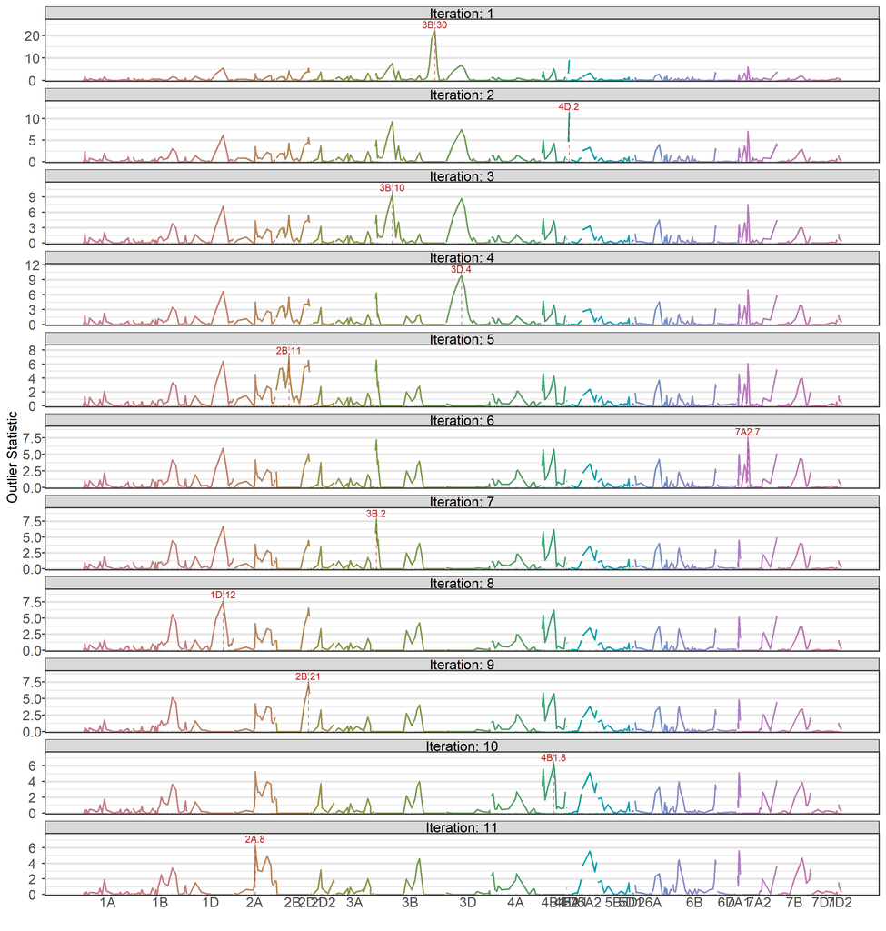

```r
plot(qtl_yld, genObj = rxk, type = "outlier", sig.col = "firebrick")
```

### 6.2 Scaled genome-wide BLUPs — `type = "blups"`

The BLUPs plot displays the scaled posterior means of all interval effects from the composite random term at each iteration. Intervals close to a detected QTL naturally shrink as the QTL absorbs the nearby signal:

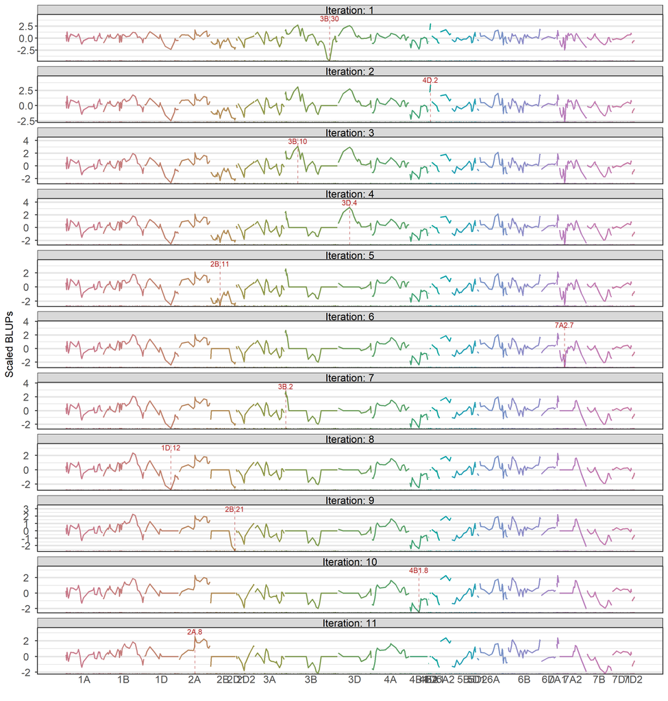

Scaled composite BLUPs across the genome at each iteration.

```r
plot(qtl_yld, genObj = rxk, type = "blups", sig.col = "firebrick")
```

### 6.3 Allele effects — `type = "effects"`

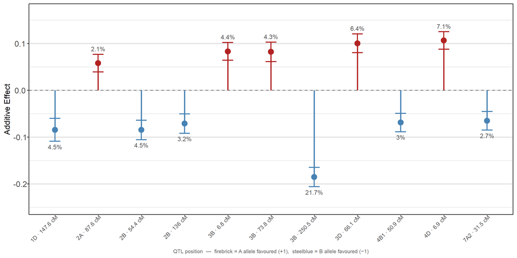

Allele effects and percentage variance explained for each detected QTL.

```r
plot(qtl_yld, genObj = rxk, type = "effects")
```

### 6.4 Allele contrast — `type = "contrast"`

The contrast plot displays the total genetic value for each line against its allele class at each detected QTL. The total genetic value combines three components: the composite genome-wide BLUP, the residual line-level genetic effect, and the summed fixed QTL contributions $\sum_k \hat{\beta}_k x_{ik}$.

This plot requires `phenoData` — the augmented data frame that `qtlAim()` automatically assigns to your calling environment at the end of the analysis. `phenoData` contains the original phenotypic columns plus `Gomit` and the `X.<chr>.<idx>` genotype columns for each detected QTL. The raw `pheno` frame would not work here as it does not contain those columns.

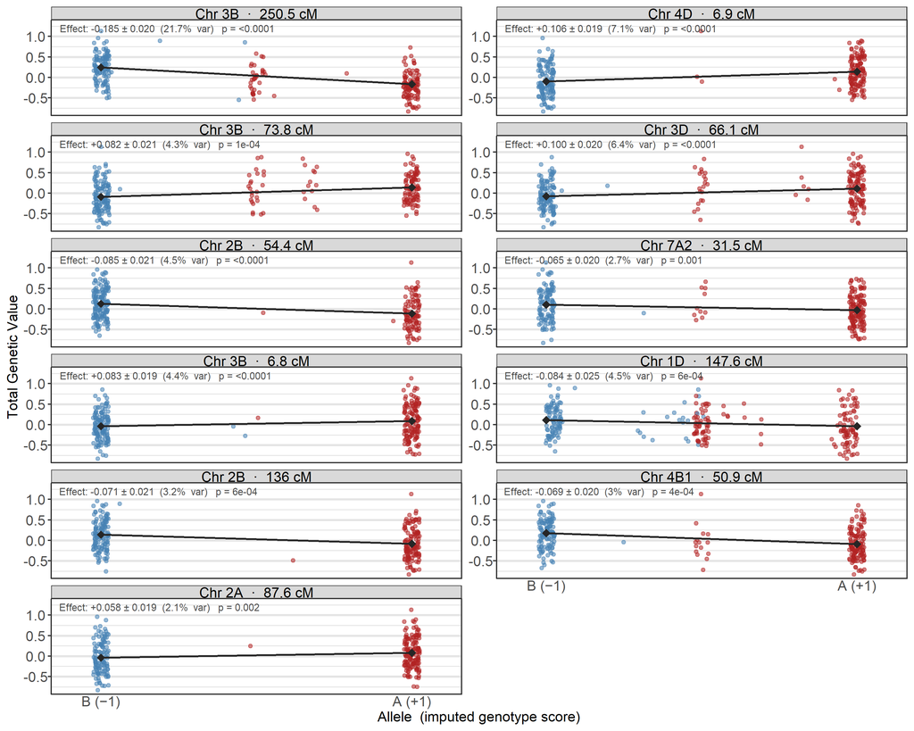

Total genetic value by allele class at each detected QTL, faceted in two columns. Firebrick = RAC875 (A, +1) allele favoured; steelblue = Kukri (B, −1) allele favoured. Group means ± SE are overlaid.

```r
plot(qtl_yld, genObj = rxk, type = "contrast", data = phenoData, ncol = 2)
```

### 6.5 Iteration heatmap — `type = "heatmap"`

The heatmap gives a compact genome × iteration view, filling each cell with the outlier statistic. This makes it easy to see which chromosomal regions carried persistent signal across multiple iterations:

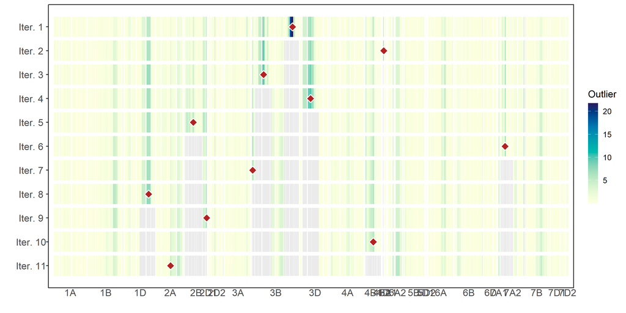

Iteration × genome heatmap of the outlier statistic. Darker cells indicate stronger signal.

```r
plot(qtl_yld, genObj = rxk, type = "heatmap", sig.col = "firebrick")
```

### 6.6 Linkage map overlay — `linkMap()`

`linkMap()` overlays the detected QTL positions onto the genetic map, with flanking markers bracketing each QTL position:

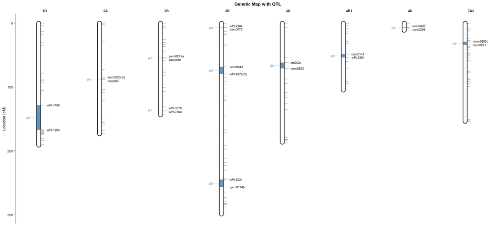

Linkage map with detected QTL positions and marker names. Brackets show flanking markers.

```r
linkMap(qtl_yld, genObj = rxk, marker.names = "all")
```

## 7 Iteration Diagnostics — `aimTrace()`

`aimTrace()` traces how the LRT statistic and QTL effect estimates evolved across iterations, providing a useful diagnostic for assessing the stability of the detected QTL.

### 7.1 LRT trace — `plot = "lrt"`

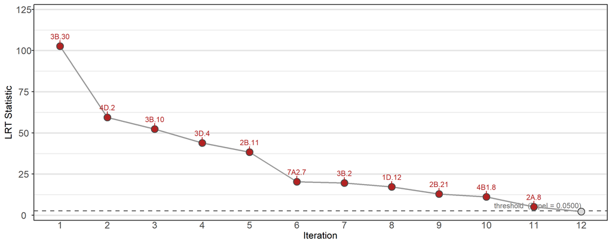

```r
aimTrace(qtl_yld, plot = "lrt", print.out = FALSE)
```

### 7.2 Effect stability — `plot = "stability"`

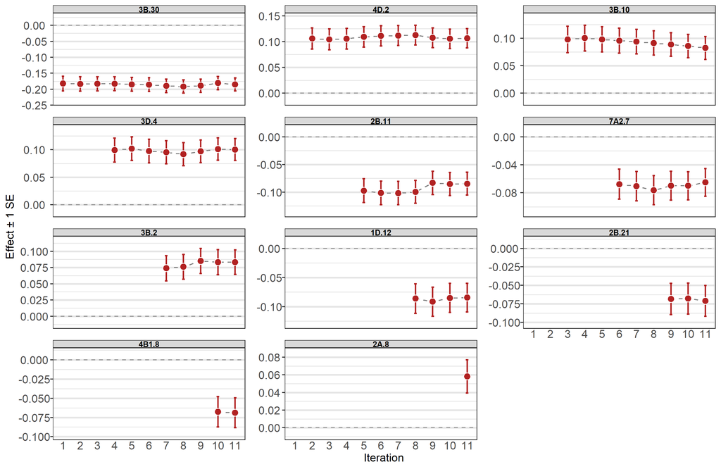

QTL allele effect estimates ± 1 SE across the iterations in which each QTL was present in the model.

```r
aimTrace(qtl_yld, plot = "stability", print.out = FALSE, ncol = 3)
```

## 8 Fine Mapping — `fineMap()`

`fineMap()` performs a high-resolution single-QTL scan in a window around each detected QTL, holding all other detected effects fixed in the model. For `qtlAim` objects it constructs a dense inferred marker grid across the window using Haldane interpolation, then fits each candidate interval in turn and reports the resulting LOD score profile.

```r
fm <- fineMap(qtl_yld, genObj = rxk,
              qtl    = c("Chr.3B.30", "Chr.3D.4", "Chr.3B.10", "Chr.4D.2"),
              window = 40,
              step   = 2,
              exclusion.window = 50)
```

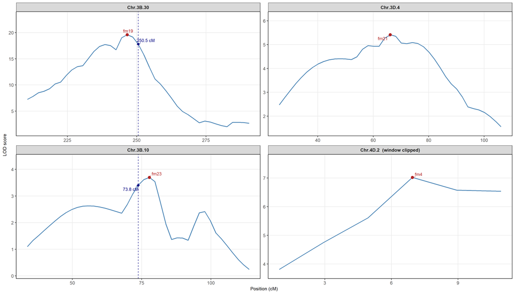

```r
plot(fm, ncol = 2)
```

## 9 Summary

The complete pipeline illustrated in this vignette is:

```r
# 1. Prepare genotype data
rxk      <- primeCross(genoRxK, type = "interval", id = "Genotype")

# 2. Fit base model (no genomic term)
base_yld <- asreml(yld ~ Range, random = ~ Genotype + Row, data = pheno, ...)

# 3. QTL mapping
qtl_yld  <- qtlAim(base_yld, genObj = rxk, merge.by = "Genotype", ...)

# 4. Results
summary(qtl_yld, genObj = rxk)          # final QTL table
plot(qtl_yld,    genObj = rxk, type = "outlier")   # genome profiles
plot(qtl_yld,    genObj = rxk, type = "blups")     # scaled BLUPs
plot(qtl_yld,    genObj = rxk, type = "effects")   # allele effects
plot(qtl_yld,    genObj = rxk, type = "contrast", data = phenoData, ncol = 2)
plot(qtl_yld,    genObj = rxk, type = "heatmap")
aimTrace(qtl_yld, plot = "lrt")
aimTrace(qtl_yld, plot = "stability", ncol = 2)
linkMap(qtl_yld,  genObj = rxk)

# 5. Fine mapping
fm <- fineMap(qtl_yld, genObj = rxk,
              qtl = c("Chr.3B.30", "Chr.3D.4", "Chr.3B.10", "Chr.4D.2"),
              window = 40, step = 2)
plot(fm, ncol = 2)
```

## 10 References

Verbyla, A.P., Cullis, B.R. & Thompson, R. (2007). The analysis of QTL by simultaneous use of the full linkage map. *Theoretical and Applied Genetics*, **116**, 95–111. https://doi.org/10.1007/s00122-007-0676-4

Verbyla, A.P., Taylor, J.D. & Verbyla, K.L. (2012). RWGAIM: An efficient high-dimensional random whole genome average (QTL) interval mapping approach. *Genetics Research*, **94**, 291–306. https://doi.org/10.1017/S0016672312000493

Taylor, J. & Verbyla, A.P. (2011). R Package wgaim: QTL Analysis in Bi-Parental Populations Using Linear Mixed Models. *Journal of Statistical Software*, **40**(7), 1–18. https://doi.org/10.18637/jss.v040.i07

Haldane, J.B.S. (1919). The combination of linkage values and the calculation of distances between the loci of linked factors. *Journal of Genetics*, **8**(29), 299–309.